# html

## Data Load

```python
import pandas as pd
import numpy as np
from datetime import datetime, timedelta
import matplotlib.pyplot as plt
import warnings
warnings.filterwarnings('ignore')
```

```python
employer_info = pd.read_csv('https://storage.googleapis.com/datalynn-datasets/interview-challenge/technology/Indeed_Ad_Pricing/employer_info.csv')
job_postings = pd.read_csv('https://storage.googleapis.com/datalynn-datasets/interview-challenge/technology/Indeed_Ad_Pricing/job_postings.csv')
```

## Question 1

**Historical Data Analysis:** Based on the `job_postings` table, identify any trends or anomalies in the historic_demand for job postings. How does demand change with seasonality, job_category, and location?

## Solution:

### Hints:

1. Let's calculate basic summary statistics using describe() and plot the histogram for the historic_demand column to get a sense of the data distribution.
2. Let's analyze and plot for seasonal, job category and location trends

```python
# Summary statistics
demand_summary = job_postings['historic_demand'].describe()
print(demand_summary)
```

```
count    5000.000000
mean      901.704646
std       435.880472
min       160.875213
25%       547.124110
50%       816.745304
75%      1178.641567
max      3084.132658
Name: historic_demand, dtype: float64
```

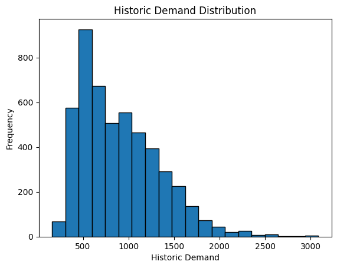

```python
# Histogram for historic_demand
plt.hist(job_postings['historic_demand'], bins=20, edgecolor='k')
plt.xlabel('Historic Demand')
plt.ylabel('Frequency')
plt.title('Historic Demand Distribution')
plt.show()
```

```python
# Analyze Seasonal Trends
seasonal_demand = job_postings.groupby('season')['historic_demand'].mean()
print(seasonal_demand)
```

```
season
Autumn    901.034233
Spring    907.281472
Summer    892.347494
Winter    905.463437
Name: historic_demand, dtype: float64
```

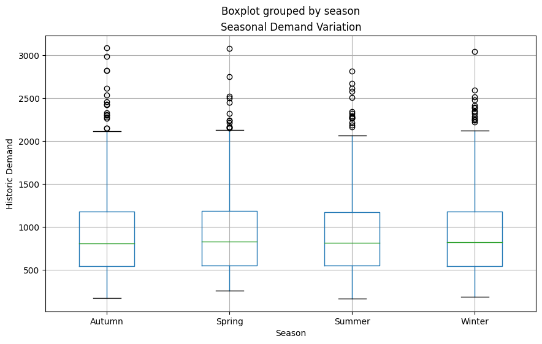

```python
# Create a larger figure and axis
fig, ax = plt.subplots(figsize=(10, 6))

# Create the boxplot
job_postings.boxplot(column='historic_demand', by='season', ax=ax)
plt.xlabel('Season')
plt.title('Seasonal Demand Variation')  # Add a title if desired
plt.ylabel('Historic Demand')
plt.show()
```

```python
# Analyze Job Category Trends
job_category_demand = job_postings.groupby('job_category')['historic_demand'].mean()
print(job_category_demand)
```

```
job_category
Education       602.438936
Engineering    1270.398543
Finance        1047.072325
Healthcare      884.034052
Hospitality     479.751968
IT             1493.213732
Retail          544.071558
Name: historic_demand, dtype: float64
```

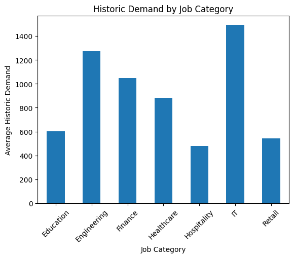

```python
# Bar chart for job category demand
job_category_demand.plot(kind='bar')
plt.title('Historic Demand by Job Category')
plt.ylabel('Average Historic Demand')
plt.xlabel('Job Category')
plt.xticks(rotation=45)
plt.show()
```

```python
# Analyze Location Trends
location_demand = job_postings.groupby('location')['historic_demand'].mean()
print(location_demand)
```

```
location
Chicago           826.026690
Dallas            770.941822
Los Angeles       923.143576
Miami             807.502143
New York          906.254335
San Francisco    1176.787368
Seattle           885.386293
Name: historic_demand, dtype: float64
```

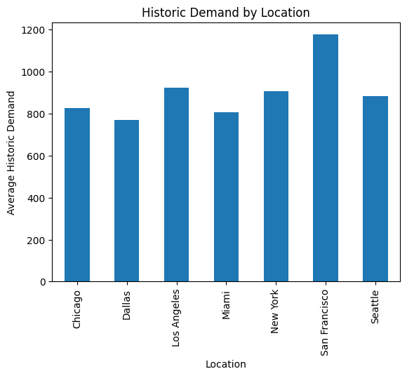

```python
# Bar chart for location demand
location_demand.plot(kind='bar')
plt.title('Historic Demand by Location')
plt.ylabel('Average Historic Demand')
plt.xlabel('Location')
plt.xticks(rotation=90)
plt.show()
```

## Question 2:

**Predictive Modeling:** Using the `job_postings` table, build a predictive model to forecast the demand for a job posting. Ensure to validate your model's accuracy. Consider `historic_demand`, `job_category`, `location`, and `season` as your predictors. Your target variable will be the `price` charged for the job posting.

## Solution:

### Hints:

1. Data Preprocessing: Encode categorical variables
2. Split the data into training and testing sets to train and evaluate the model's performance.
3. Choose an appropriate machine learning algorithm for regression.

Common regression algorithms include Linear Regression, Random Forest Regressor, and Gradient Boosting Regressor.

4. Train the selected model on the training data.
5. Evaluate the model's performance on the testing dataset using appropriate regression metrics such as mean squared error.

```python
from sklearn.model_selection import train_test_split
from sklearn.linear_model import LinearRegression
from sklearn.metrics import mean_absolute_error, mean_squared_error, r2_score
from sklearn.preprocessing import OneHotEncoder

# Encode categorical variables (job_category, location, season)
encoder = OneHotEncoder(sparse=False)
encoded_features = encoder.fit_transform(job_postings[['job_category', 'location', 'season']])
encoded_feature_names = encoder.get_feature_names_out(['job_category', 'location', 'season'])
encoded_df = pd.DataFrame(encoded_features, columns=encoded_feature_names)


# Combine encoded features with numeric predictors (historic_demand)
X = pd.concat([encoded_df, job_postings[['historic_demand']]], axis=1)

# Target variable (price)
y = job_postings['price']

# Split the data into training and testing sets (e.g., 80% train, 20% test)
X_train, X_test, y_train, y_test = train_test_split(X, y, test_size=0.2, random_state=42)

# Create and train a Linear Regression model
model = LinearRegression()
model.fit(X_train, y_train)

# Make predictions on the test set
y_pred = model.predict(X_test)

# Evaluate the model's performance
mse = mean_squared_error(y_test, y_pred)

# Print evaluation metrics
print("Mean Squared Error (MSE):", mse)
```

```
Mean Squared Error (MSE): 119.97437579786848
```

## Question 3:

**Bayesian Approach:** Based on the employer's past `response_rate` from the `employer_info` table, what is the probability that an employer with a response rate exceeding 60% will pay above the average price for a job posting?

## Solution:

### Hints:

1. Calculate the average price for a job posting based on the data you have.
2. Filter employer with a response rate exceeding 60%. Then compute the probability.

```python
# average price for a job posting
average_price = employer_info['avg_price'].mean()

# employer with a response rate exceeding 60%
above_60 = employer_info[employer_info['response_rate'] > 0.6]['avg_price'] > average_price

above_60.sum()/len(above_60)
```

```
0.4666666666666667
```

## Question 4:

**Advanced Insights with Joint Analysis:** Employers might have a trend in the amount they're willing to pay based on their historic response rates. Can you generate insights by joining the `employer_info` and `job_postings` table to estimate the potential price for a new job posting for a given employer?

## Solution:

### Hints:

- 1: Compute the average of historic demand per employer
- 2: Merge the data
- 3: Model Building
- 4: Model Evaluation

```python
# Step 1 Compute the average of historic demand per employer
avg_historic_demand_per_employer = job_postings.groupby('employer_id')[['historic_demand']].mean()

# Step 2: Merge the data
merged_data = pd.merge(avg_historic_demand_per_employer, employer_info, on='employer_id')

# Step 3: Model Building
X = merged_data[['response_rate', 'historic_demand']]
y = merged_data['avg_price']

X_train, X_test, y_train, y_test = train_test_split(X, y, test_size=0.2, random_state=42)

model = LinearRegression()
model.fit(X_train, y_train)

# Step 4: Model Evaluation
y_pred = model.predict(X_test)
mse = mean_squared_error(y_test, y_pred)

print(f'Mean Squared Error: {mse}')
```

```
Mean Squared Error: 142.01958621157024
```